# Predicting academic performance using demographic and behavioral Data

Author

Zhengling Jiang, Colombe Tolokin, Franklin Aryee, Tien Nguyen

## 1 Summary

This project investigates whether a student’s mathematics performance can be predicted using demographic and behavioral data, aiming to help educators in supporting students and tailoring educational strategies. Using a Ridge Regression model with optimized hyperparameters (alpha = 1), we achieved a strong predictive accuracy with a cross-validation score of 0.81. Evaluation metrics on the test set including an MSE of 4.048, RMSE of 2.012, and MAE of 1.309. While the model demonstrates robust performance, future work could explore non-linear models and provide confidence intervals for predictions to enhance interpretability and reliability, ultimately contributing to better educational outcomes.

## 2 Introduction

Math teaches us to think logically and it also provides us with analytical and problem-solving skills. These skills can be applied to various academic and professional fields. However, student performance in mathematics can be influenced by many factors, like individual factor, social factor, and family factor. Research has shown that attributes such as study habits, age, social behavior (alcohol consumption, etc) and family background can significantly impact a student’s academic success. Understanding these factors is crucial for improving educational outcomes. (Bitrus, Apagu, and Hamsatu (2016), Hjarnaa et al. (2023), Modi (2023))

In this study, we aim to address this question: **“Can we predict a student’s math academic performance based on the demographic and behavioral data?”**. Answering this question is crucial, as it can help educators identify and support struggling students more effectively. Furthermore, the ability to predict academic performance could assist schools in developing educational strategies tailored to students’ diverse backgrounds. The goal of this study is to develop a machine learning model capable of predicting student’s math performance with high accuracy.

The dataset (Cortez (2008)) used in this study contains detailed records of student demographics and behaviors, such as age, study habits, social behaviors, and family background. The target variable, mathematics performance, is measured as a continuous score reflecting students’ final grade. This dataset offers a great opportunity to explore meaningful relationships between features and academic outcomes.

## 3 Methods & Results

### 3.1 Dataset Description

The full dataset contains the following columns:

1. `school` - student’s school (binary: ‘GP’ - Gabriel Pereira or ‘MS’ - Mousinho da Silveira)
2. `sex` - student’s sex (binary: ‘F’ - female or ‘M’ - male)
3. `age` - student’s age (numeric: from 15 to 22)
4. `address` - student’s home address type (binary: ‘U’ - urban or ‘R’ - rural)
5. `famsize` - family size (binary: ‘LE3’ - less or equal to 3 or ‘GT3’ - greater than 3)
6. `Pstatus` - parent’s cohabitation status (binary: ‘T’ - living together or ‘A’ - apart)
7. `Medu` - mother’s education (numeric: 0 - none, 1 - primary education (4th grade), 2 - “ 5th to 9th grade, 3 - “ secondary education or 4 - “ higher education)
8. `Fedu` - father’s education (numeric: 0 - none, 1 - primary education (4th grade), 2 - “ 5th to 9th grade, 3 - “ secondary education or 4 - “ higher education)
9. `Mjob` - mother’s job (nominal: ‘teacher’, ‘health’ care related, civil ‘services’ (e.g. administrative or police), ‘at_home’ or ‘other’)
10. `Fjob` - father’s job (nominal: ‘teacher’, ‘health’ care related, civil ‘services’ (e.g. administrative or police), ‘at_home’ or ‘other’)
11. `reason` - reason to choose this school (nominal: close to ‘home’, school ‘reputation’, ‘course’ preference or ‘other’)
12. `guardian` - student’s guardian (nominal: ‘mother’, ‘father’ or ‘other’)
13. `traveltime` - home to school travel time (numeric: 1 - <15 min., 2 - 15 to 30 min., 3 - 30 min. to 1 hour, or 4 - >1 hour)
14. `studytime` - weekly study time (numeric: 1 - <2 hours, 2 - 2 to 5 hours, 3 - 5 to 10 hours, or 4 - >10 hours)
15. `failures` - number of past class failures (numeric: n if 1<=n<3, else 4)
16. `schoolsup` - extra educational support (binary: yes or no)
17. famsup` - family educational support (binary: yes or no)
18. `paid` - extra paid classes within the course subject (Math or Portuguese) (binary: yes or no)
19. `activities` - extra-curricular activities (binary: yes or no)
20. `nursery` - attended nursery school (binary: yes or no)
21. `higher` - wants to take higher education (binary: yes or no)
22. `internet` - Internet access at home (binary: yes or no)
23. `romantic` - with a romantic relationship (binary: yes or no)
24. `famrel` - quality of family relationships (numeric: from 1 - very bad to 5 - excellent)
25. `freetime` - free time after school (numeric: from 1 - very low to 5 - very high)
26. `goout` - going out with friends (numeric: from 1 - very low to 5 - very high)
27. `Dalc` - workday alcohol consumption (numeric: from 1 - very low to 5 - very high)
28. `Walc` - weekend alcohol consumption (numeric: from 1 - very low to 5 - very high)
29. `health` - current health status (numeric: from 1 - very bad to 5 - very good)
30. `absences` - number of school absences (numeric: from 0 to 93)

These columns represent the grades:

- G1 - first period grade (numeric: from 0 to 20)
- G2 - second period grade (numeric: from 0 to 20)
- G3 - final grade (numeric: from 0 to 20, output target)

*Attribution*: The dataset variable description is copied as original from the [UCI Machine Learning Repository](https://archive.ics.uci.edu/dataset/320/student+performance).

### 3.2 Data Loading, Wrangling and Summary

Let’s start by loading the data and reviewing the dataset’s structure.

The file is a `.csv` file with `;` as delimiter. Let’s use `pandas`to read it in.

This provides an overview of the dataset with 33 columns, each representing student attributes such as age, gender, study time, grades, and parental details.

Let’s get some information on the dataset to better understand it.

|  | school | sex | age | address | famsize | Pstatus | Medu | Fedu | Mjob | Fjob | ... | famrel | freetime | goout | Dalc | Walc | health | absences | G1 | G2 | G3 |
| --- | --- | --- | --- | --- | --- | --- | --- | --- | --- | --- | --- | --- | --- | --- | --- | --- | --- | --- | --- | --- | --- |
| 0 | GP | F | 18 | U | GT3 | A | 4 | 4 | at_home | teacher | ... | 4 | 3 | 4 | 1 | 1 | 3 | 6 | 5 | 6 | 6 |
| 1 | GP | F | 17 | U | GT3 | T | 1 | 1 | at_home | other | ... | 5 | 3 | 3 | 1 | 1 | 3 | 4 | 5 | 5 | 6 |
| 2 | GP | F | 15 | U | LE3 | T | 1 | 1 | at_home | other | ... | 4 | 3 | 2 | 2 | 3 | 3 | 10 | 7 | 8 | 10 |
| 3 | GP | F | 15 | U | GT3 | T | 4 | 2 | health | services | ... | 3 | 2 | 2 | 1 | 1 | 5 | 2 | 15 | 14 | 15 |
| 4 | GP | F | 16 | U | GT3 | T | 3 | 3 | other | other | ... | 4 | 3 | 2 | 1 | 2 | 5 | 4 | 6 | 10 | 10 |

5 rows × 33 columns

```
<class 'pandas.core.frame.DataFrame'>
RangeIndex: 395 entries, 0 to 394
Data columns (total 33 columns):
 #   Column      Non-Null Count  Dtype
---  ------      --------------  -----
 0   school      395 non-null    object
 1   sex         395 non-null    object
 2   age         395 non-null    int64
 3   address     395 non-null    object
 4   famsize     395 non-null    object
 5   Pstatus     395 non-null    object
 6   Medu        395 non-null    int64
 7   Fedu        395 non-null    int64
 8   Mjob        395 non-null    object
 9   Fjob        395 non-null    object
```

[output cut: 25 more lines]

The dataset contains 395 observations and 33 columns covering different aspects of student demographics, academic and behavioral traits.

We can see that there is no missing values. There is not need to handle NAs.

The dataset includes categorical (school, sex, Mjob) and numerical (age, G1, G2, G3) features.

There is a large range of features but not all of them are necessary for this analysis. Let’s proceed and select only the necessary ones.

Let’s selected the following key columns:

- Demographic attributes: sex, age
- Academic Attributes: studytime, failures, G1, G2, G3 (grades for three terms)
- Behavioral Attributes: goout (socializing), Dalc (weekday alcohol consumption), Walc (weekend alcohol consumption)

We will split the dataset into train and test set with a 80/20 ratio then set `random_state=123` for reproducibility.

#### 3.2.1 Data Validation Checks

From heatmap shown in Figure 1, we observe no missing values, suggesting the dataset is entirely complete.

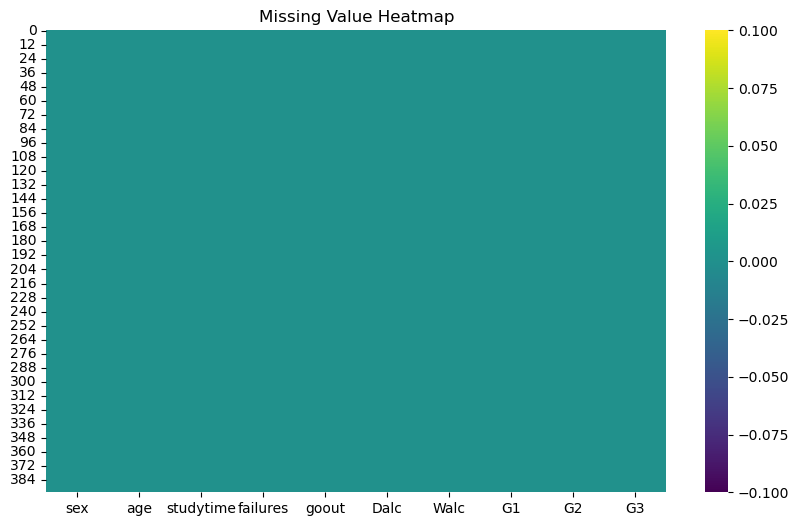

Figure 1: Missing Values Heatmap

The histogram in Figure 2 visualizes the spread of the target variable. This distribution is critical to understanding how the target behaves and whether any transformations are needed to ensure better model performance.

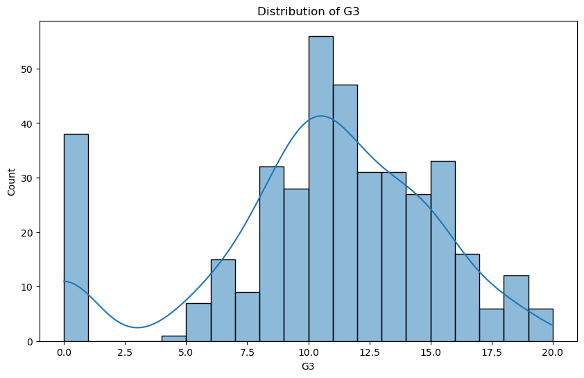

Figure 2: Distribution of the target variable

#### 3.2.2 Checking for Outliers

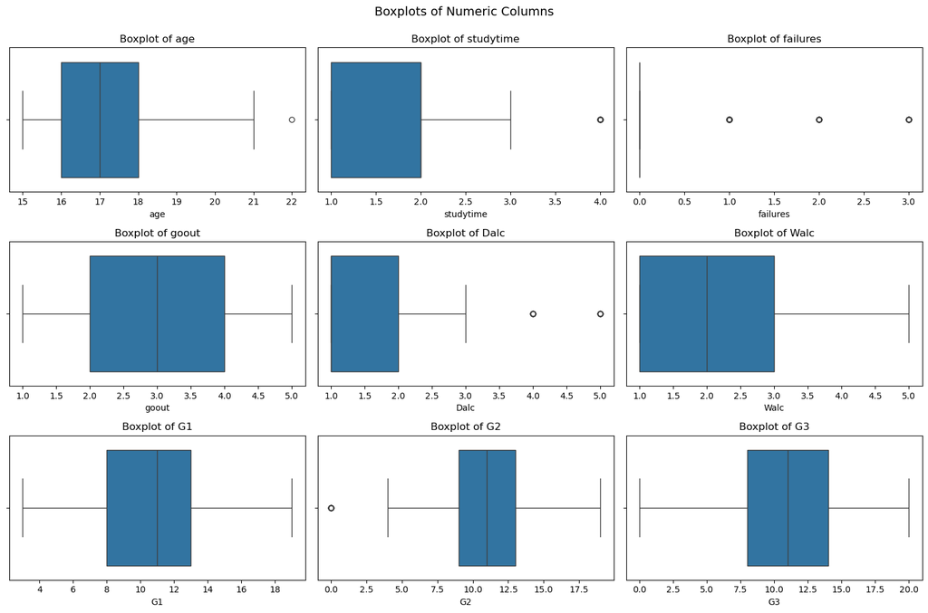

Figure 3: Visualization of Outliers

```
<class 'pandas.core.frame.DataFrame'>
RangeIndex: 316 entries, 0 to 315
Data columns (total 10 columns):
 #   Column     Non-Null Count  Dtype
---  ------     --------------  -----
 0   sex        316 non-null    object
 1   age        316 non-null    int64
 2   studytime  316 non-null    int64
 3   failures   316 non-null    int64
 4   goout      316 non-null    int64
 5   Dalc       316 non-null    int64
 6   Walc       316 non-null    int64
 7   G1         316 non-null    int64
 8   G2         316 non-null    int64
 9   G3         316 non-null    int64
dtypes: int64(9), object(1)
memory usage: 24.8+ KB
```

Let’s get a summary of the training set we are going to use for the analysis.

Table 1: Summary statistics for columns

|  | age | studytime | failures | goout | Dalc | Walc | G1 | G2 | G3 |
| --- | --- | --- | --- | --- | --- | --- | --- | --- | --- |
| count | 316 | 316 | 316 | 316 | 316 | 316 | 316 | 316 | 316 |
| mean | 16.7563 | 2.05063 | 0.360759 | 3.0981 | 1.47152 | 2.30696 | 10.8354 | 10.6013 | 10.2627 |
| std | 1.29006 | 0.860398 | 0.770227 | 1.11833 | 0.855874 | 1.2589 | 3.25208 | 3.7568 | 4.52268 |
| min | 15 | 1 | 0 | 1 | 1 | 1 | 4 | 0 | 0 |
| 25% | 16 | 1 | 0 | 2 | 1 | 1 | 8 | 8.75 | 8 |
| 50% | 17 | 2 | 0 | 3 | 1 | 2 | 11 | 11 | 11 |
| 75% | 18 | 2 | 0 | 4 | 2 | 3 | 13 | 13 | 13 |
| max | 22 | 4 | 3 | 5 | 5 | 5 | 19 | 19 | 20 |

Let’s create a visualization to explore the final grades `G3` distribution. We will use a histogram as it allows us to see the spread.

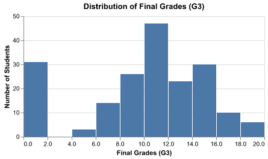

Figure 4: Distribution of Final Grades (G3)

From Figure 4, The histogram shows that most students achieve grades between 8 and 15, with fewer students scoring very low or very high.

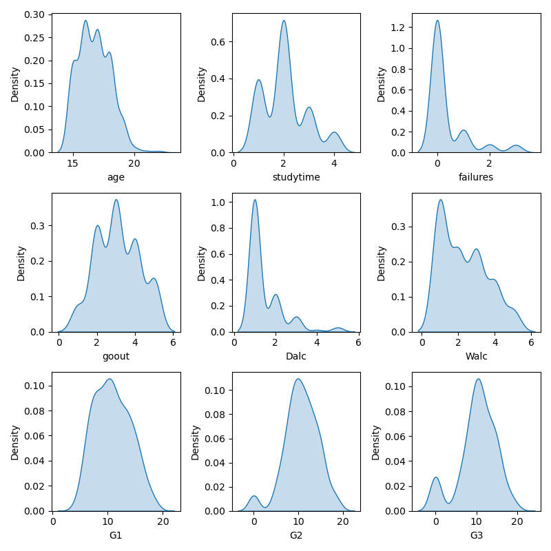

Figure 5: Density plot for each numeric columns

Some interesting observations from Figure 5 :

- The distribution of the grades `G3`, `G2`, `G1` are somewhat bell-shaped.
- Most student do not consume alcohol, or very minimally.
- Most student studied around 2-5 hours a week and most of them also did not fail any previous classes.

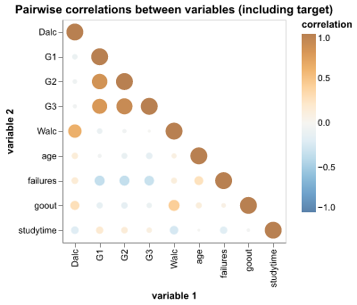

Figure 6: Correlation matrices for each numeric column

Some interesting observations from Figure 6:

- The grades are significantly correlated to one another.
- Alcohol consumptions are somewhat negatively correlated with grades.
- Study time are somewhat positively correlated with grades.

### 3.3 Analysis

We begin our analysis by preparing the data, splitting it into features and target variables for both training and testing. To establish a baseline for comparison, we fit a DummyRegressor and evaluate its performance. Following this, we preprocess the data by identifying categorical and numerical features, applying scaling to the numeric features and one-hot encoding to the categorical ones. A Ridge regression model is then incorporated into a pipeline, and we fine-tune its hyperparameters using grid search with 5-folds cross-validation to optimize its performance. Finally, we evaluate the model on the test set, analyze the observed versus predicted values, and review the cross-validation results to assess the overall model effectiveness.

### 3.4 Model Evaluation

The Table 2 below summarizes the performance metrics of the model on the test dataset. The metrics used for evaluation are MSE, RMSE, and MAE.

- Mean Squared Error (MSE): The average of squared differences between predicted and actual values, giving more weight to larger errors.
- Root Mean Squared Error (RMSE): The square root of MSE, expressing errors in the same units as the data.
- Mean Absolute Error (MAE): The average absolute difference between predicted and actual values, showing overall prediction accuracy.

We use these metrics to evaluate model performance and understand how well predictions align with actual values, with each providing unique insights into error magnitude and distribution.

Table 2: Performance metrics on test data

| Metric | Value |
| --- | --- |
| Mean Squared Error (MSE) | 4.04828 |
| Root Mean Squared Error (RMSE) | 2.01203 |
| Mean Absolute Error (MAE) | 1.3086 |

Next, we analyze the coefficients of the Ridge regression model. The Table 3 shows the values of the coefficients, which indicate the importance of each feature in predicting the target variable.

Table 3: Coefficients of Ridge model

| features | coefs |
| --- | --- |
| age | -0.351724 |
| studytime | -0.129035 |
| failures | 0.101029 |
| goout | 0.225087 |
| Dalc | 0.00580251 |
| Walc | 0.0437156 |
| G1 | 0.539314 |
| G2 | 3.65733 |
| sex_M | 0.0262267 |

The following Figure 7 visualizes the coefficients of the Ridge regression model. Features with higher absolute coefficients have more impact on the model’s predictions.

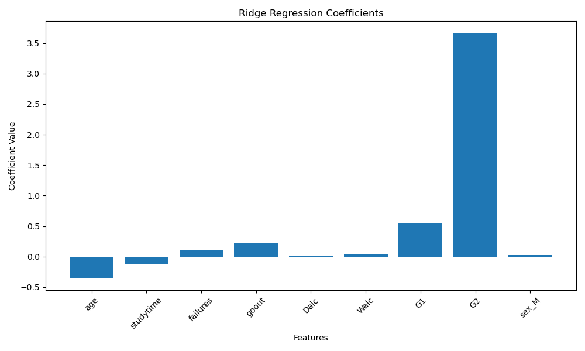

Figure 7: Ridge regression coefficients.

## 4 Results & Discussion

The Ridge Regression model, with tuned hyperparameters, demonstrated well predictive capabilities on student’s math performance. The optimal hyperparameter for Ridge was found to be alpha = 1, and the best cross-validation score is approximately 0.81. This indicates a strong predictive accuracy during the model’s validation phase.

Based on the evaluation on the test set, the model achieved the following performance metrics:

- Mean Squared Error (MSE): 4.048
- Root Mean Squared Error (RMSE): 2.012
- Mean Absolute Error (MAE): 1.309

These metrics suggest that the model is reasonably accurate in predicting students’ final grades. However, there are areas for improvement. We can explore other models which could better capture the non-linear relationships and feature interactions. Another improvement we can do is to provide confidence intervals for predictions. This approach could enhance the reliability and interpretability of predictions and help readers make more informed decisions.

## 5 References

Bitrus, GA, KB Apagu, and PJ Hamsatu. 2016. “Marital Status and Age as Predictors of Academic Performance of Students of Colleges of Education in the Nort-Eastern Nigeria.” *American Journal of Educational Research* 4 (12): 896–902.

Cortez, Paulo. 2008. “Student Performance.” 2008. https://doi.org/10.24432/C5TG7T.

Hjarnaa, Louise, Sanne Pagh Møller, Alberte Brix Curtis, Ulrik Becker, Ove Andersen, Fartein Ask Torvik, and Janne Schurmann Tolstrup. 2023. “Alcohol Intake and Academic Performance and Dropout in High School: A Prospective Cohort Study in 65,233 Adolescents.” *Journal of Adolescent Health* 73 (6): 1083–92.

Modi, Yushi Girishkumar. 2023. “The Impact of Stress on Academic Performance: Strategies for High School Students.” *International Journal of Psychiatry* 8 (5): 150–52.